# Juvenile Snowshoe Hares: Exploratory Report

Jonah Seif

11/18/2020

##### By: Jonah Seif

## a. Introduction

This report provides an exploratory overview of the differences in juvenile Snowshoe hare sizes for both male and female hares observed across three sites in the Bonanza Creek Experimental Forest from 1999 - 2012 (Kielland et al 2017). Specifically, juvenile hare counts are compared over this period as well as the relationship between sex and weight. Furthermore, the relationship between hind foot length and weight is explored in juvenile Snowshoe hares.

## b. Data and Analyses

The data for Snowshoe hare measurements were collected and made available by senior investigator Dr. Knut Kielland and colleagues at the Bonanza Creek Experimental Forest (Kielland et al 2017). The data contain observations of Snowshoe hares, Lepus americanus, from 5 locales in the Tanana valley, collected from 1999 - 2012. Following exploratory data visualization, weights between male and female penguins are by two-sample t-tests using a significance level (α) of 0.05 throughout. Differences between groups are described by Cohen’s d effect size. The relationship between hind foot length and weight is explored by simple linear regression. All analyses are in R version 4.0.2 using RStudio version 1.3.1073.

## c. Exploratory Findings

#### I. Annual juvenile hare trap counts

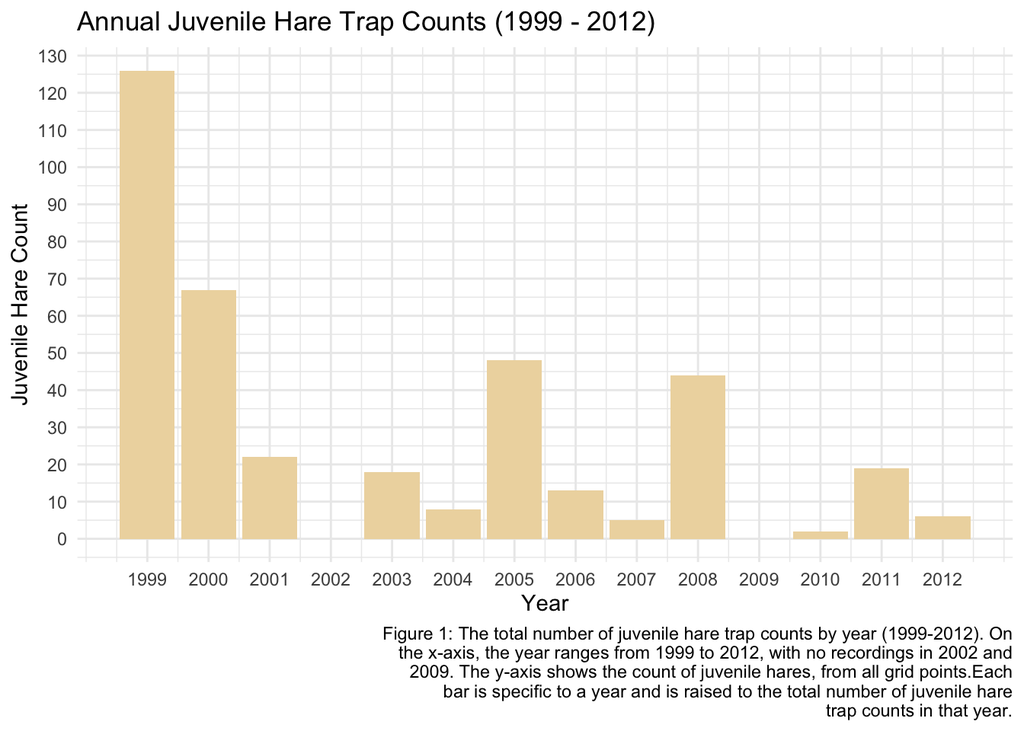

The data shows that the highest recorded number of juvenile hares was in 1999 with 126, while the lowest count was in 2010 with 2. The mean value of juvenile hares over the 12 years of data was 31.5 per year. The general trend appears to be a decline in juvenile hare numbers since 1999, but effort may affect the values. In order to standardize the juvenile hare population in future analyses, it would be beneficial to use the same number of traps on the same days every year. This could account for seasonal patterns and ensure consistency in recorded data.

#### II. Juvenile hare weights

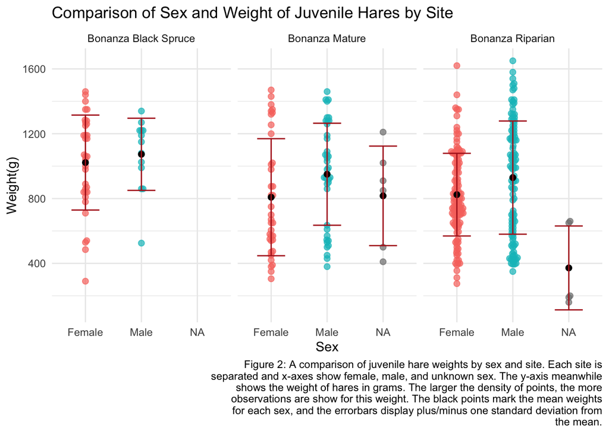

In general, we see that mean weights of juvenile male hares is slightly more that juvenile female weights. The least difference in means occurs at the Bonanza Black Spruce site, where observations were the lowest. At this site, it is possible that a low-end outlier in female weight slightly impacted the mean results. Comparatively, at the Bonanza Riparian site, a high-end outlier in female weight would have less of an effect on the mean since there are more observations. The standard deviation lines demonstrate the range where roughly 68% of expected population weights would be detected.